# Mutation Signatures in Experimental Data

This is intitial analysis of some experimental data to understand what kinds of mutational signatures are observed, and how they compare with the data found in Alexandrov 2013.

The software being used here is from Blokzijl, Janssen, Van Boxtel, and Cuppen. Manual: http://bioconductor.org/packages/release/bioc/vignettes/MutationalPatterns/inst/doc/MutationalPatterns.pdf

Dependencies

If Bioconductor needs to be upgraded.

Install necessary Bioconductor packages.

Alternatively the newest version can be installed from github.

```r
library(devtools)
install_github("UMCUgenetics/MutationalPatterns")
```

Download reference genomes from bioconductor.

Load Necessary Libraries.

```r
suppressMessages(library(BSgenome))
suppressMessages(library(MutationalPatterns))
ref_genome <- "BSgenome.Hsapiens.UCSC.hg19"
suppressMessages(library(ref_genome, character.only = TRUE))
```

Once the data is downloaded if can then be manually loaded.

```r
vcf_files <- list.files(pattern = ".vcf", full.names = TRUE)
sample_names = c("realData", "realData2")
#vcfs <- read_vcfs_as_granges(vcf_files, sample_names, genome = "hg19")
vcfs <- read_vcfs_as_granges(vcf_files, sample_names, genome = "BSgenome.Hsapiens.UCSC.hg19")
```

[output not shown]

```r
summary(vcfs)
```

```
     Length       Class        Mode
          2 GRangesList          S4
```

The particular base subsitutions can be read in from the specified vcf file into a vcf object in the form of “REF>ALT”.

```r
head(mutations_from_vcf(vcfs[[1]]), 10)
```

```
 [1] "G>A" "G>A" "G>A" "G>T" "G>T" "G>T" "C>T" "T>C" "G>T" "C>T"
```

The base changes can also be converted to the 6 conventional base substitution types.

```r
head(mutation_types(vcfs[[1]]), 10)
```

```
 [1] "C>T" "C>T" "C>T" "C>A" "C>A" "C>A" "C>T" "T>C" "C>A" "C>T"
```

In order to retrieve the context in which the mutations appear use the following method.

```r
head(mutation_context(vcfs[[1]], ref_genome), 10)
```

```
 chr1  chr1  chr1  chr1  chr1  chr1  chr1  chr1  chr1  chr1
"CGT" "TGG" "GGG" "GGG" "GGG" "GGT" "TCT" "CTG" "TGC" "GCT"
```

The occurances of each triplet can then be counted.

```r
type_occurrences <- mut_type_occurrences(vcfs, ref_genome)
print(type_occurrences)
```

|  | C>A | C>G | C>T | T>A | T>C | T>G | C>T at CpG | C>T other |
| --- | --- | --- | --- | --- | --- | --- | --- | --- |
| realData | 731 | 34 | 952 | 723 | 399 | 38 | 77 | 875 |

The mutation spectrum functions take into consideration the number of occurrences at different sites. The `plot_spectrum` function plots the mean relative contribution of each of the 6 different base substitution types over multiple samples.

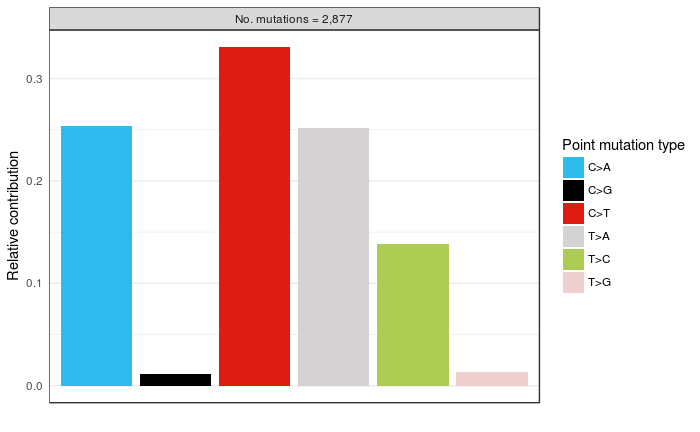

```r
# default plot
p1 <- plot_spectrum(type_occurrences)
plot(p1)
```

As an example of the uncorrected bias that I have seen in experimental data, look at the following plot. I do not yet understand why the two mutation biases do not entirely match.

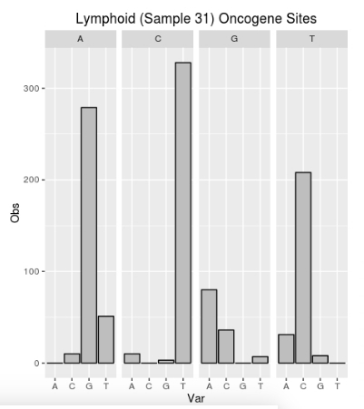

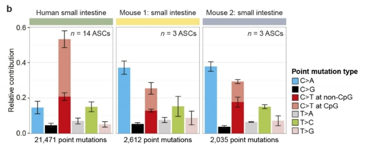

We can also separate out the C-T changes that have occurred at CpG islands. I think what this illustrates nicely is that our C-T bias is not as strong as the bias that is observed by other labs, but this appears to be due to the fact that I do not have an accurate representation of the fraction of the genome that contains CpG sequences within my probed regions.

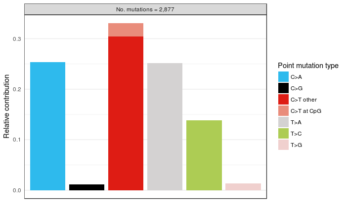

```r
p2 <- plot_spectrum(type_occurrences, CT = TRUE)
plot(p2)
```

Below is the 96 mutation profile for my experimental data. Interestingly the triple base pair pattern that I observed is essentially the exact opposite of the pattern I observe in the Stratton lab data. When a pattern of change is more prevalent in their data, that pattern is less prevalent in my data. For reference, three organs from the Stratton lab are included after my data.

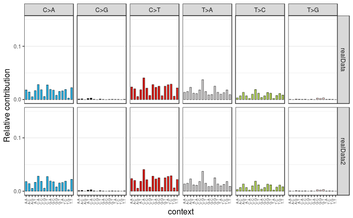

```r
mut_mat <- mut_matrix(vcf_list = vcfs, ref_genome = ref_genome)
plot_96_profile(mut_mat[,c(1,2)])
```

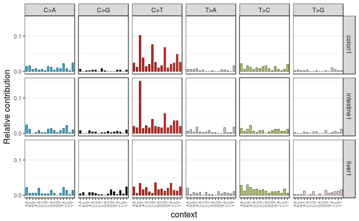

Stratton Lab 96 Mutation Patterns

7.1 Strand Bias Testing The idea here is to test whether variants are found on the transcribed or non-transcribed strand. This may be useful in understanding the involvement of transcription-coupled repair. The output will be “-” (outside of genes) “T” (transcribed/anti-sense/non-coding strand) and “U” (untranscribed/sense/coding strand).

First download the known gene regions from UCSC

```r
# Get ``known genes'' table from UCSC for hg19
biocLite("TxDb.Hsapiens.UCSC.hg19.knownGene")
```

Then load the gene regions.

```r
suppressMessages(library("TxDb.Hsapiens.UCSC.hg19.knownGene"))
genes_hg19 <- genes(TxDb.Hsapiens.UCSC.hg19.knownGene)
```

Calculate strand information.

```r
strand_from_vcf(vcfs[[1]], genes_hg19)
```

```
Error in mergeNamedAtomicVectors(seqlengths(x), seqlengths(y), what = c("sequence",  :
  sequence chr19 has incompatible seqlengths:
  - in 'x': 53576266
  - in 'y': 59128983
```

Strand information can then be incorporated into the mutation matrix information.

```r
mut_mat_s <- mut_matrix_stranded(vcfs, ref_genome, genes_hg19)
head(mut_mat_s, 10)
```

[output not shown]

Strand bias analysis can then be plotted.

```r
strand_counts <- strand_occurrences(mut_mat_s, by=tissue)
plot_strand(strand_counts, mode = "relative")
```

[output not shown]

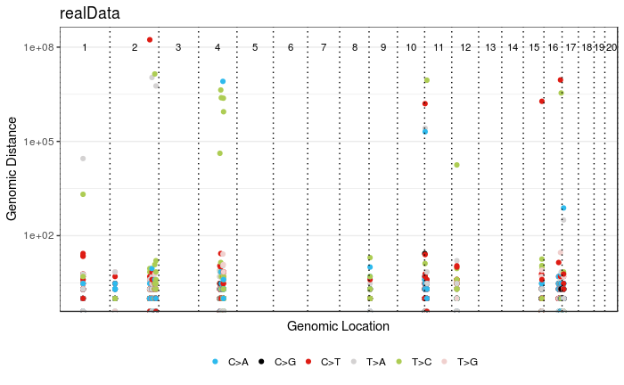

```r
# Define autosomal chromosomes
chromosomes <- seqnames(get(ref_genome))[1:22]
# Make a rainfall plot
plot_rainfall(vcfs[[1]], title = names(vcfs[1]),
chromosomes = chromosomes, cex = 1.5)
```

Rainfall plots for each chromosome individually.

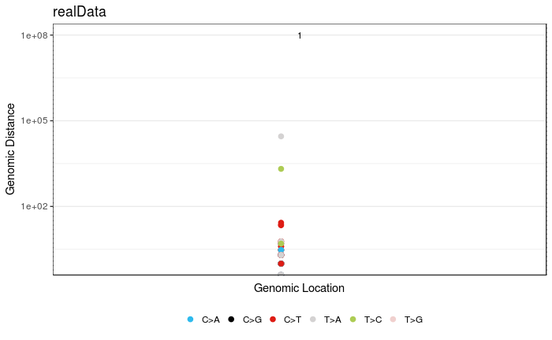

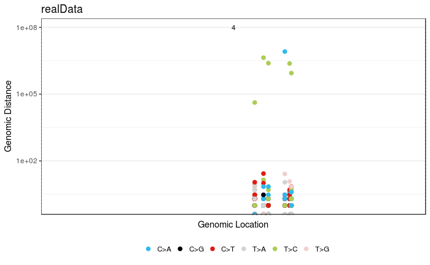

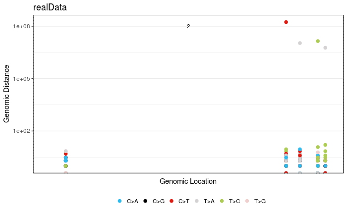

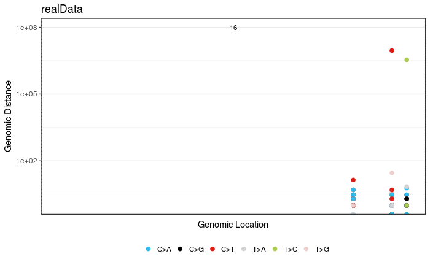

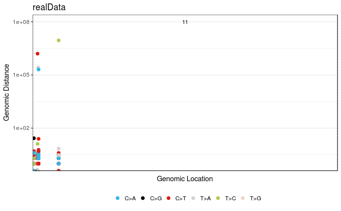

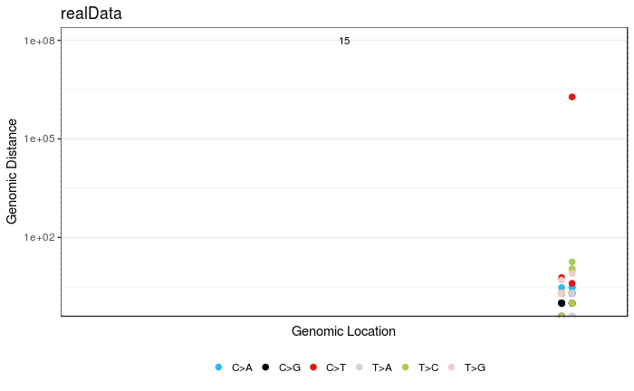

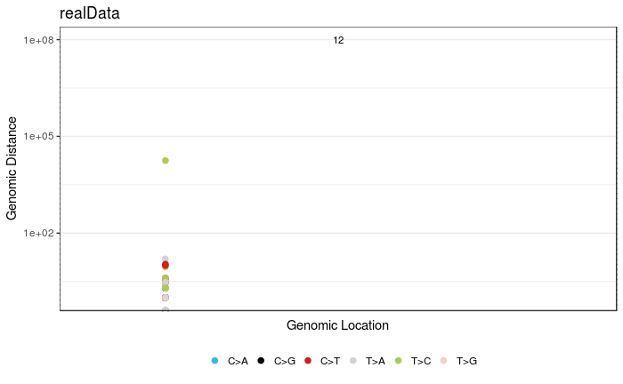

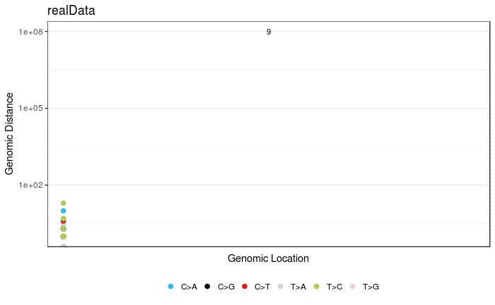

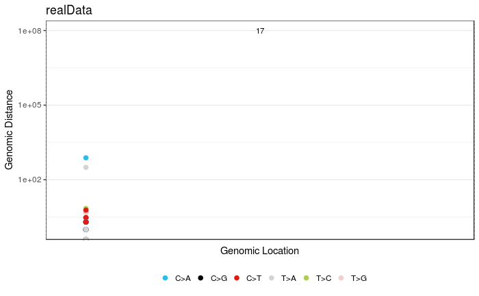

```r
for (i in c(1,2,4,9,11,12,15,16,17)){
    chromosomes <- seqnames(get(ref_genome))[i]
    x = plot_rainfall(vcfs[[1]], title = names(vcfs[1]),
    chromosomes = chromosomes[1], cex = 2)
    plot(x)
}
```